# R Notebook

TODO: We all knew birds nest but who knew that data frames nest, too?

```r
library(here)
library(tidyverse)
library(magrittr)
library(stringr)
library(lubridate)
library(rgbif)
library(sp)
library(rgdal)
library(raster)
library(tidymodels)
library(glmnet)
library(caret)
library(rasterVis)
library(viridis)
library(ggthemes)
library(gganimate)
```

The Scottish Crossbill (**Loxia scotica**) is a small passerine bird that inhabits the Caledonian Forests of Scotland, and is the only terrestrial vertebrate species unique to the United Kingdom. Only ~ 20000 individuals of this species are alive today.

The first step is to get occurrence data for the species we are interested in. This used to be the main challenge in Biogeography. Natural Historians such as Charles Darwin, Alfred Russel Wallace, and Alexander von Humboldt would travel for years on rustic sail ships around the globe collecting specimen. Today, we are standing on the shoulders of giants. Getting data is fast and easy thanks to the work of two organisations:

- [the Global Biodiversity Information Facility (GBIF)](https://www.gbif.org/), an international network and research infrastructure funded by the world’s governments and aimed at providing anyone, anywhere, open access to data about all types of life on Earth.
- [rOpenSci](https://ropensci.org/), a non-profit initiative that has developed an ecosystem of open source tools, we run annual unconferences, and review community developed software.

```r
# Cute finces with funny beaks don't only occur in the Galapagos islands
# (https://www.datacamp.com/courses/statistical-thinking-in-python-part-2)
# THIS ONLY NEEDS TO RUN ONCE!
# convert scientific (Latin) name to gbif taxon ID
# (Good to avoid synonyms, which are common with english species names)
speciesKey <- rgbif::name_backbone('Loxia scotica')$speciesKey
# get the occurrence records of this species
gbif_response <- occ_search(
  scientificName = "Loxia scotica",
  country = "GB",
  hasCoordinate = TRUE,
  hasGeospatialIssue = FALSE,
  limit = 9999)
# backup to reduce API load
write_rds(
  x = gbif_response,
  path = here::here('data/gbif_occs_loxsco.rds')
)
# # to read file back in:
# gbif_response <- read_rds(path = here::here('data/gbif_response_loxsco.rds'))
```

GBIF and rOpenSci just saved us years or roaming around the highlands with a pair of binoculars, camping in mud, rain, and snow, and chasing crossbills through the forest. Nevertheless, it is still up to us to make sense of the data we got back, in particular to clean it, as data collected on this large scale can have its own issues. Luckily, GBIF provides some useful metadata on each record. Here, I will exclude those that

```r
# look at a random sub-sample of the data (100 rows)
# we can see there is a lot of information on each record!
gbif_response$data %>% sample_n(100)
```

```
# A tibble: 100 x 83
   name     key decimalLatitude decimalLongitude issues datasetKey publishingOrgKey networkKeys
   <chr>  <int>           <dbl>            <dbl> <chr>  <chr>      <chr>            <chr>
 1 Loxi… 1.50e9            57.0            -2.81 ""     3d6c8883-… c71f0513-c95a-4… none
 2 Loxi… 1.50e9            57.4            -3.55 ""     3d6c8883-… c71f0513-c95a-4… none
 3 Loxi… 1.70e9            57.0            -3.58 ""     efb3f1a0-… 90e9563c-9e64-4… none
 4 Loxi… 1.18e9            57.1            -3.74 ""     4fa7b334-… e2e717bf-551a-4… none
 5 Loxi… 5.91e8            57.2            -3.70 cdrou… 4fa7b334-… e2e717bf-551a-4… none
 6 Loxi… 1.70e9            55.6            -5.14 ""     efb3f1a0-… 90e9563c-9e64-4… none
 7 Loxi… 1.77e9            57.2            -3.70 cdrou… 4fa7b334-… e2e717bf-551a-4… none
 8 Loxi… 1.50e9            58.0            -4.72 ""     3d6c8883-… c71f0513-c95a-4… none
 9 Loxi… 1.66e9            54.8            -5.66 cdrou… c779b049-… d3f94e8a-bb06-4… none
10 Loxi… 1.50e9            57.3            -4.98 ""     dbfff627-… c71f0513-c95a-4… none
# ... with 90 more rows, and 75 more variables: installationKey <chr>, publishingCountry <chr>,
#   protocol <chr>, lastCrawled <chr>, lastParsed <chr>, crawlId <int>, extensions <chr>,
#   basisOfRecord <chr>, taxonKey <int>, kingdomKey <int>, phylumKey <int>, classKey <int>,
#   orderKey <int>, familyKey <int>, genusKey <int>, speciesKey <int>, acceptedTaxonKey <int>,
#   scientificName <chr>, acceptedScientificName <chr>, kingdom <chr>, phylum <chr>, order <chr>,
#   family <chr>, genus <chr>, species <chr>, genericName <chr>, specificEpithet <chr>,
#   taxonRank <chr>, taxonomicStatus <chr>, dateIdentified <chr>, stateProvince <chr>, year <int>,
#   month <int>, day <int>, eventDate <chr>, lastInterpreted <chr>, license <chr>, identifiers <chr>,
#   facts <chr>, relations <chr>, geodeticDatum <chr>, class <chr>, countryCode <chr>, country <chr>,
#   identifier <chr>, recordedBy <chr>, catalogNumber <chr>, institutionCode <chr>, locality <chr>,
#   county <chr>, collectionCode <chr>, gbifID <chr>, occurrenceID <chr>, individualCount <int>,
#   coordinateUncertaintyInMeters <dbl>, eventID <chr>, occurrenceStatus <chr>, vernacularName <chr>,
#   taxonConceptID <chr>, identifiedBy <chr>, recordNumber <chr>, sex <chr>, preparations <chr>,
#   nomenclaturalCode <chr>, verbatimEventDate <chr>, verbatimTaxonRank <chr>,
#   higherClassification <chr>, continent <chr>, footprintWKT <chr>, endDayOfYear <chr>,
#   samplingEffort <chr>, datasetName <chr>, taxonID <chr>, ownerInstitutionCode <chr>,
#   startDayOfYear <chr>
```

```r
birds_clean <- gbif_response$data %>%
  # get decade of record from eventDate
  mutate(decade = eventDate %>%
           ymd_hms() %>%
           round_date("10y") %>%
           year() %>%
           as.numeric()) %>%
  # clean data using metadata filters
  filter(
    # only records with no issues
    issues == "" &
    # only creative commons license records
    str_detect(license, "http://creativecommons.org/") &
    # no records before 1965
    decade >= 1970 &
    # no records after 2015 (there is not a lot of data yet)
    decade < 2020) %>%
  # retain only relevant variables
  # (note: select is a name conflict between the raster package the dplyr.
  # I am therefore explicitly calling dplyr::select here)
  dplyr::select(decimalLongitude, decimalLatitude, decade) %>%
  # sort by decade
  arrange(decade)
```

```
 143 failed to parse.
```

Okay so we’ve got clean data now. Here comes the nifty trick. We want to look at the data in subsets by decade in order to see if and how the spatial distribution of the species has changed over time. To do so, we can “nest” data in a list column using the `tidyr` package:

```r
birds_nested <- birds_clean %>%
  # define the nesting index
  group_by(decade) %>%
  # aggregate data in each group
  nest()
# let's have a look
head(birds_nested)
```

```
# A tibble: 5 x 2
  decade data
   <dbl> <list>
1   1970 <tibble [5 × 2]>
2   1980 <tibble [4 × 2]>
3   1990 <tibble [8 × 2]>
4   2000 <tibble [363 × 2]>
5   2010 <tibble [431 × 2]>
```

```r
# latlon crs reference
proj_latlon <- CRS("+proj=longlat +datum=WGS84 +ellps=WGS84 +towgs84=0,0,0")
proj_ukgrid <- CRS("+init=epsg:27700")
birds_nested <- birds_nested %>%
  # make records into spatial points
  mutate(points = map(
    .x = data,
    .f = ~ SpatialPoints(coords = .x, proj4string = proj_latlon) %>%
      # reproject spatial points to the UK grid
      # (this is so it matches our climate data)
      spTransform(CRSobj = proj_ukgrid)))
```

We also need climate data for our analysis. I have prepared this separately based on a dataset provided by the UK Met Office. It is nested in the same way as the bird data (although I admit that nesting weather seems slighly less straight forward than nesting birds).

If you would like to learn more about raster data and how to work with it you can check out the [datacamp course on spatial analysis in R](https://www.datacamp.com/courses/spatial-analysis-in-r-with-sf-and-raster)

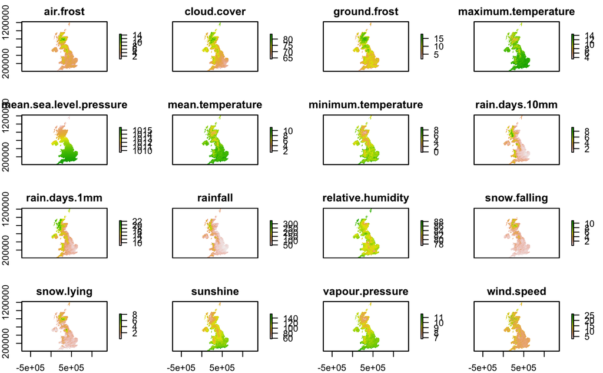

```r
# read raster data
climate_nested <- read_rds(here::here("data/ukcp09_stacked_rasters.rds"))
# plot 1970
plot(climate_nested$raster_stacks[[1]])
```

For our purpose of model fitting we will combine the corresponding bird and climate datasets by joining them together using decade. This allows us to subsequently extract the climatic conditions at a location that the bird was observed at, in the decade that it was observed.

```r
# check that the two datasets match up
stopifnot(all(climate_nested$decade == birds_nested$decade))
# combine climate and bird data
locs_withbirds <- data_frame(
  decade = birds_nested$decade,
  presence = 1,
  climate =  map2(
    .x = climate_nested$raster_stacks,
    .y = birds_nested$points,
    .f = ~ as_data_frame(raster::extract(.x, .y))))
# get number of records per decade
n_points <- map_dbl(.x = birds_nested$data, .f = nrow)
# create a random sample from the rasters to use as absence data
locs_nobirds <- data_frame(
  decade = birds_nested$decade,
  presence = 0,
  # draw random sample from climate data
  climate = map2(
    .x = climate_nested$raster_stacks,
    .y = n_points * 5,
    .f = ~ as_tibble(sampleRandom(.x, size = .y, cells = FALSE))))
# combine the two datasets
df_nested <- bind_rows(locs_withbirds, locs_nobirds) %>%
  unnest() %>%
  group_by(decade) %>%
  nest()
df_nested
```

```
# A tibble: 5 x 2
  decade data
   <dbl> <list>
1   1970 <tibble [30 × 17]>
2   1980 <tibble [24 × 17]>
3   1990 <tibble [48 × 17]>
4   2000 <tibble [2,178 × 17]>
5   2010 <tibble [2,586 × 17]>
```

```r
# last pre-processing step
df_modelling <- df_nested %>%
  # get into modelling format
  unnest() %>%
  # caret requires a factorial response variable for classification
  mutate(presence = case_when(
    presence == 1 ~ "presence",
    presence == 0 ~ "absence") %>%
    factor()) %>%
  # drop all observations with NA variables
  na.omit()
# create a training set for the model build
df_train <- df_modelling %>%
  # true temporal split as holdout
  filter(decade != "2010") %>%
  # drop decade, it's not needed anymore
  dplyr::select(-decade)
# same steps for test set
df_test <- df_modelling %>%
  filter(decade == "2010") %>%
  dplyr::select(-decade)
```

Caret makes the model fitting incredibly easy! All we need to do is specify a tuning grid of hyperparameters that we want to optimise, a tune control that adjusts the number of iterations and the loss function used, and then call train with the algorithm we have picked.

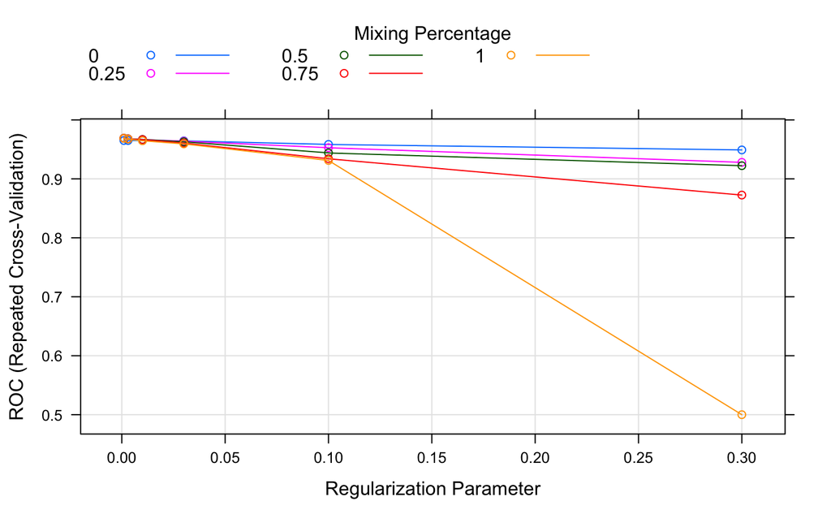

```r
# for reproducibility
set.seed(12345)
# set up model fitting parameters
# tuning grid, trying every possible combination
tuneGrid <- expand.grid(
  alpha = seq(0, 1, length = 5),
  lambda = c(.001, .003, .01, .03, .1, .3))
tuneControl <- trainControl(
  method = 'repeatedcv',
  classProbs = TRUE,
  number = 10,
  repeats = 1,
  verboseIter = TRUE,
  summaryFunction = twoClassSummary)
# actual model build
model_fit <- train(
  presence ~ .,
  data = df_train,
  method = "glmnet",
  family = "binomial",
  metric = "ROC",
  tuneGrid = tuneGrid,
  trControl = tuneControl)
plot(model_fit)
```

We can evaluate the performance of this model on our hold-out data from 2010. Just as uring training we are using the Area under the Receiver Operator Characteristic curve (AUC). With this metric, a model no bettern than random would score 0.5 while a perfect model making no mistakes would score 1.

```r
# combine prediction with validation set
df_eval <- data_frame(
  "obs" = df_test$presence,
  "pred" = predict(
    object = model_fit,
    newdata = df_test,
    type = "prob") %>%
    pull(1))
# get ROC value
roc_auc_vec(estimator = "binary", truth = df_eval$obs, estimate = df_eval$pred)
```

```
[1] 0.9627021
```

That is a pretty good result! However, I am worried that we may be slightly overfitting

```r
# model_fit <- update(
#   object = model_fit,
#   param = list(alpha = .5, lambda = .3))
```

```r
df_eval
```

[output not shown]

```r
# code to remove cells with missing values in any decade
no_na_data <- df_eval %>%
  dplyr::select(decade, climate_data, habitat_suitability) %>%
  # change nesting
  unnest() %>% group_by(x, y) %>% nest() %>%
  # find cells with missing values
  mutate(any_na = map_lgl(
      .x = data,
      ~ dim(.x)[[1]] == 5)) %>%
  # exclude them
  filter(any_na) %>%
  dplyr::select(x, y, data) %>%
  unnest()
hs_animation <- no_na_data %>%
  dplyr::select(x, y, decade, habitat_suitability) %>%
  gather(key = "variable", value = "value", -x, -y, -decade) %>%
  filter(variable == "habitat_suitability") %>%
  # plot data
  ggplot(aes(x = x, y = y, fill = value)) +
  geom_tile() +
  # good colour palette for colour blind people
  scale_fill_viridis(option = "A") +
  coord_equal() +
  theme_map() +
  theme(legend.position = "bottom") +
  # animate plot, morphing through decades
  transition_states(
    states = decade,
    transition_length = 5,
    state_length = 2) +
  labs(title = 'Habitat Suitability per Decade',
    # gganimate: animate subtitle
    subtitle = 'Decade: {closest_state}',
    caption = 'Source:\nGBIF data and\nMetOffice UK climate data',
    fill = 'Habitat Suitability [0 low - high 1]')
```